# Praca domowa 5

Piotr Miziński

20 listopada 2018

## Cel

Celem tej pracy domowej było sprawdzenie, czy w społeczeństwie wciąż występują problemy z czytaniem wykresów. Zdecydowano się sprawdzić, czy wykresy kołowe 3D, naprawdę powodują aż tyle problemów z odczytywaniem danych.

## Opis ankiety

W celu sprawdzenia powyższej tezy, sporządzono anietę, na której poproszono ankieterów (niezwiązanych ze światkiem wizualizacji danych), w której przetestowano postrzeganie tych samych zbiorów danych na wykresach kołowych oraz słupkowych. Na potrzeby ankiety stworzono jeden zbiór danych, zawierający grupy od A do I, którym przyporządkowano wartości procentowe, sumujące się do 100. Następnie stworzono 3 wersje tego samego zbioru danych, jednak z przepermutowanymi wartościami dla niektórych, lub wszystkich grup. Miało to na celu sprawdzenie, czy położenie danego fragmentu “pie-charta” ma znaczenie przy postrzeganiu jego wartości. Wersje wykresów kołowych i słupkowych odpowiadały sobie, tzn. prezentowały zbiór danych przepermutowny w ten sam sposób. Poniżej pokazno kolejno zbiór 3 wykresów kołowych i słupkowych.

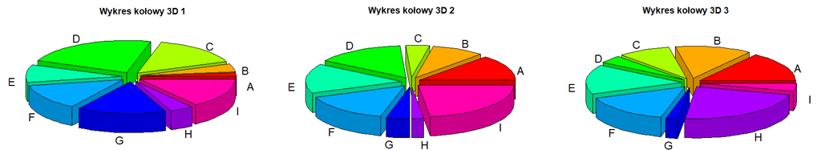

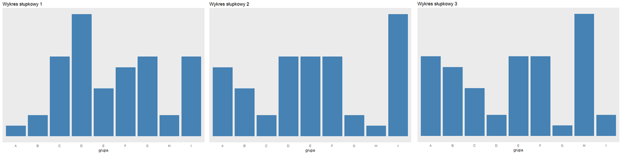

Link do ankiety: https://docs.google.com/forms/d/e/1FAIpQLSccZLiCT-YDiOtZ469EevBQ30u03Xd82cfaEWR-TsYYFHW7NA/viewform?fbclid=IwAR23726tSnvlZ33ex72694izKsQgZ598P6xSm05wAE0ry6D9ELze0ZU1hlI

## Wyniki ankiety i podsumowanie

W ankiecie więło udział 15 osób, które nie uczęszczały na wykład z wizualizacji danych, więc nie są świadome zagrożeń w percepcji postrzegania wykresów kołowych.

Dla pierwszej permutacji zbioru danych:

- wykres kołowy: 14 złych odpowiedzi, 1 dobra
- wykres słupkowy: 3 złe odpwiedzi, 11 dobrych, 1 nieważna

Dla drugiej permutacji zbiorów danych:

- wykres kołowy: 15 złych odpowiedzi, 0 dobrych
- wykres słupkowy: 5 złych odpwiedzi, 10 dobrych

Dla trzeciej permutacji zbioru danych:

- wykres kołowy: 15 złych odpowiedzi, 0 dobrych
- wykres słupkowy: 2 złe odpwiedzi, 11 dobrych, 2 nieważne

Podsumowując ankieterzy częściej mylili się układając kolejność grup odczytywaną z wykresów kołowych. Błędy polegały zarówno na przyrównywaniu grup o różnych wartościach liczbowych, jak i zamianach kolejności tych mniejszych z wiekszymi. Najlepiej wypadła permutacja 1, gdzie jednemu z akieterów udało się odgadnąć poprawną odpowiedź. Dla wykresów słupkowych przeważały odpowiedzi poprawne, aczkolwiek, dla drugiej permutacji udzielono aż 5 złych odpowiedzi. Mogło to być spowodowane monotonnością ankiety i znużeniem ankieterów na jej ostatnich etapach, co znalazło odbicie, również w udzielaniu odpowiedzi nieważnych (wpisywanie tych smaych grup kilkukrotnie lub ich pomijanie).

Generalnie, z analizy wyników przeprowadzonej ankiety można wysnuć wnioski, że wykresy kołowe, zwłaszcza w 3D, zasłużenie są owiane złą sławą.